# Course - Supervised Learning

##### NOTE:

1. Your code MUST execute without any errors.
2. You can add more lines in your code as required.

# Section 1: Basic Statistical Concepts

# Question 1

#### The dataset is loaded for you. Perform the following tasks:

1. Compute basic statistical measures for each of the variables from the freeny dataset.
2. Construct a correlation matrix for all the variables in the freeny dataset.
3. Create a new variable price.income.ratio constructed as a ratio of price.index and income.level. Print its summary statistics.

```r
library(datasets)
```

```r
head(freeny)
```

|  | y | lag.quarterly.revenue | price.index | income.level | market.potential |
| --- | --- | --- | --- | --- | --- |
| 1962.25 | 8.79236 | 8.79636 | 4.70997 | 5.82110 | 12.9699 |
| 1962.5 | 8.79137 | 8.79236 | 4.70217 | 5.82558 | 12.9733 |
| 1962.75 | 8.81486 | 8.79137 | 4.68944 | 5.83112 | 12.9774 |
| 1963 | 8.81301 | 8.81486 | 4.68558 | 5.84046 | 12.9806 |
| 1963.25 | 8.90751 | 8.81301 | 4.64019 | 5.85036 | 12.9831 |
| 1963.5 | 8.93673 | 8.90751 | 4.62553 | 5.86464 | 12.9854 |

```r
#1.Compute basic statistical measures for each of the variables from the freeny dataset.
#MEAN
mean(freeny$y)
mean(freeny$lag.quarterly.revenue)
mean(freeny$price.index)
mean(freeny$income.level)
mean(freeny$market.potential)
```

9.30630435897436

9.28071769230769

4.49618153846154

6.0385958974359

13.0668307692308

```r
#MEDIAN
median(freeny$y)
median(freeny$lag.quarterly.revenue)
median(freeny$price.index)
median(freeny$income.level)
median(freeny$market.potential)
```

9.31378

9.28436

4.51018

6.06093

13.0693

```r
#MODE
which.max(table(freeny$y))
which.max(table(freeny$lag.quarterly.revenue))
which.max(table(freeny$price.index))
which.max(table(freeny$income.level))
which.max(table(freeny$market.potential))
```

**8.79137:** 1

**8.79137:** 1

**4.30909:** 5

**5.8211:** 1

**12.9699:** 1

```r
#Range
max(freeny$y,na.rm = TRUE) - min(freeny$y,na.rm = TRUE)
max(freeny$lag.quarterly.revenue,na.rm= TRUE) - min(freeny$lag.quarterly.revenue,na.rm = TRUE)
max(freeny$price.index,na.rm = TRUE) - min(freeny$price.index,na.rm = TRUE)
max(freeny$income.level,na.rm = TRUE) - min(freeny$income.level,na.rm = TRUE)
max(freeny$market.potential,na.rm = TRUE) - min(freeny$market.potential,na.rm = TRUE)
```

1.00287

0.983989999999999

0.43208

0.3792

0.196499999999999

```r
#Interquartile-Range
IQR(freeny$y)
IQR(freeny$lag.quarterly.revenue)
IQR(freeny$price.index)
IQR(freeny$income.level)
IQR(freeny$market.potential)
```

0.546255

0.540929999999999

0.21335

0.191135000000001

0.117800000000001

```r
#Variance
var(freeny$y)
var(freeny$lag.quarterly.revenue)
var(freeny$price.index)
var(freeny$income.level)
var(freeny$market.potential)
```

0.0996139326515519

0.0995199757182185

0.0177840559554656

0.0145065583300945

0.00416075744939268

```r
#standard deviation
sd(freeny$y)
sd(freeny$lag.quarterly.revenue)
sd(freeny$price.index)
sd(freeny$income.level)
sd(freeny$market.potential)
```

0.315616749637201

0.31546786796474

0.133356874421477

0.120443174692859

0.0645039335962752

```r
#2.Construct a correlation matrix for all the variables in the freeny dataset.
#install.packages("corrplot")
library(corrplot)
```

[output not shown]

[output not shown]

```r
data <- freeny
data[is.na(data)] = 0
cor_matrix <- cor(data)
cor_matrix
```

|  | y | lag.quarterly.revenue | price.index | income.level | market.potential |
| --- | --- | --- | --- | --- | --- |
| y | 1.0000000 | 0.9977945 | -0.9895118 | 0.9839382 | 0.9965928 |
| lag.quarterly.revenue | 0.9977945 | 1.0000000 | -0.9894174 | 0.9816602 | 0.9972070 |
| price.index | -0.9895118 | -0.9894174 | 1.0000000 | -0.9538757 | -0.9890884 |
| income.level | 0.9839382 | 0.9816602 | -0.9538757 | 1.0000000 | 0.9765025 |
| market.potential | 0.9965928 | 0.9972070 | -0.9890884 | 0.9765025 | 1.0000000 |

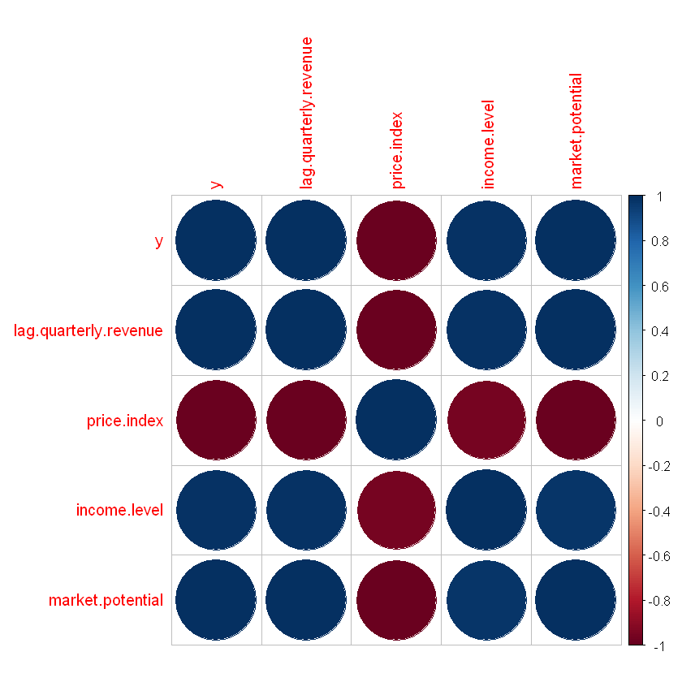

```r
corrplot(cor_matrix)
```

```r
#3.Create a new variable price.income.ratio constructed as a ratio of price.index and income.level.
#Print its summary statistics.
data["price.income.ratio"] = (data["price.index"]/data["income.level"])
data
```

|  | y | lag.quarterly.revenue | price.index | income.level | market.potential | price.income.ratio |
| --- | --- | --- | --- | --- | --- | --- |
| 1962.25 | 8.79236 | 8.79636 | 4.70997 | 5.82110 | 12.9699 | 0.8091203 |
| 1962.5 | 8.79137 | 8.79236 | 4.70217 | 5.82558 | 12.9733 | 0.8071591 |
| 1962.75 | 8.81486 | 8.79137 | 4.68944 | 5.83112 | 12.9774 | 0.8042091 |
| 1963 | 8.81301 | 8.81486 | 4.68558 | 5.84046 | 12.9806 | 0.8022622 |
| 1963.25 | 8.90751 | 8.81301 | 4.64019 | 5.85036 | 12.9831 | 0.7931461 |
| 1963.5 | 8.93673 | 8.90751 | 4.62553 | 5.86464 | 12.9854 | 0.7887151 |
| 1963.75 | 8.96161 | 8.93673 | 4.61991 | 5.87769 | 12.9900 | 0.7860078 |
| 1964 | 8.96044 | 8.96161 | 4.61654 | 5.89763 | 12.9943 | 0.7827788 |
| 1964.25 | 9.00868 | 8.96044 | 4.61407 | 5.92574 | 12.9992 | 0.7786487 |
| 1964.5 | 9.03049 | 9.00868 | 4.60766 | 5.94232 | 13.0033 | 0.7753975 |
| 1964.75 | 9.06906 | 9.03049 | 4.60227 | 5.95365 | 13.0099 | 0.7730166 |
| 1965 | 9.05871 | 9.06906 | 4.58960 | 5.96120 | 13.0159 | 0.7699121 |
| 1965.25 | 9.10698 | 9.05871 | 4.57592 | 5.97805 | 13.0212 | 0.7654536 |
| 1965.5 | 9.12685 | 9.10698 | 4.58661 | 6.00377 | 13.0265 | 0.7639550 |
| 1965.75 | 9.17096 | 9.12685 | 4.57997 | 6.02829 | 13.0351 | 0.7597461 |
| 1966 | 9.18665 | 9.17096 | 4.57176 | 6.03475 | 13.0429 | 0.7575724 |
| 1966.25 | 9.23823 | 9.18665 | 4.56104 | 6.03906 | 13.0497 | 0.7552566 |
| 1966.5 | 9.26487 | 9.23823 | 4.54906 | 6.05046 | 13.0551 | 0.7518536 |
| 1966.75 | 9.28436 | 9.26487 | 4.53957 | 6.05563 | 13.0634 | 0.7496445 |
| 1967 | 9.31378 | 9.28436 | 4.51018 | 6.06093 | 13.0693 | 0.7441399 |
| 1967.25 | 9.35025 | 9.31378 | 4.50352 | 6.07103 | 13.0737 | 0.7418049 |
| 1967.5 | 9.35835 | 9.35025 | 4.49360 | 6.08018 | 13.0770 | 0.7390571 |
| 1967.75 | 9.39767 | 9.35835 | 4.46505 | 6.08858 | 13.0849 | 0.7333483 |
| 1968 | 9.42150 | 9.39767 | 4.44924 | 6.10199 | 13.0918 | 0.7291457 |
| 1968.25 | 9.44223 | 9.42150 | 4.43966 | 6.11207 | 13.0950 | 0.7263758 |
| 1968.5 | 9.48721 | 9.44223 | 4.42025 | 6.11596 | 13.0984 | 0.7227402 |
| 1968.75 | 9.52374 | 9.48721 | 4.41060 | 6.12129 | 13.1089 | 0.7205344 |
| 1969 | 9.53980 | 9.52374 | 4.41151 | 6.12200 | 13.1169 | 0.7205995 |
| 1969.25 | 9.58123 | 9.53980 | 4.39810 | 6.13119 | 13.1222 | 0.7173322 |
| 1969.5 | 9.60048 | 9.58123 | 4.38513 | 6.14705 | 13.1266 | 0.7133715 |
| 1969.75 | 9.64496 | 9.60048 | 4.37320 | 6.15336 | 13.1356 | 0.7107011 |
| 1970 | 9.64390 | 9.64496 | 4.32770 | 6.15627 | 13.1415 | 0.7029744 |
| 1970.25 | 9.69405 | 9.64390 | 4.32023 | 6.16274 | 13.1444 | 0.7010242 |
| 1970.5 | 9.69958 | 9.69405 | 4.30909 | 6.17369 | 13.1459 | 0.6979764 |
| 1970.75 | 9.68683 | 9.69958 | 4.30909 | 6.16135 | 13.1520 | 0.6993743 |
| 1971 | 9.71774 | 9.68683 | 4.30552 | 6.18231 | 13.1593 | 0.6964258 |
| 1971.25 | 9.74924 | 9.71774 | 4.29627 | 6.18768 | 13.1579 | 0.6943265 |
| 1971.5 | 9.77536 | 9.74924 | 4.27839 | 6.19377 | 13.1625 | 0.6907570 |
| 1971.75 | 9.79424 | 9.77536 | 4.27789 | 6.20030 | 13.1664 | 0.6899489 |

```r
#Print its summary statistics.(price.income.ratio)
mean(data$price.income.ratio)#Mean
median(data$price.income.ratio)#Median
which.max(table(data$price.income.ratio))#Mode
max(data$price.income.ratio) - min(data$price.income.ratio)#Range
IQR(data$price.income.ratio)#Interquartile-Range
var(data$price.income.ratio)#Variance
sd(data$price.income.ratio)#Standard deviation
```

0.745277264036971

0.74413992572097

**0.689948873441608:** 1

0.119171395923289

0.0588551939832942

0.00134706759138125

0.0367024194213576

### Good Job! You are done with the section!

## Section 2: Machine Learning: Regression Analysis

## Question 1

#### Based on the observations acquired from the above exercise:

1. Construct a linear regression model using y as dependent variable and top 2 variables with the highest correlation with y as dependent variable.
2. Calculate the r-squared value for the constructed model.
3. Use half the dataset for training and the remaining for testing.
4. Generate in-sample and out-sample predictions and compute variance of residuals [hint: residual= y_predicted - y_observed]
5. Plot the actual and predicted results for y variable.

```r
#1.Construct a linear regression model using y as dependent variable and top 2 variables with the highest correlation with y
#as dependent variable.
model <- lm(market.potential ~ price.index + income.level ,data = freeny)
model
```

```
Call:
lm(formula = market.potential ~ price.index + income.level, data = freeny)

Coefficients:
 (Intercept)   price.index  income.level
     13.2720       -0.3093        0.1963
```

```r
#2.Calculate the r-squared value for the constructed model.
summary(model)
#Ans:-r-squared value = 0.9899
```

```
Call:
lm(formula = market.potential ~ price.index + income.level, data = freeny)

Residuals:
       Min         1Q     Median         3Q        Max
-0.0101512 -0.0054213 -0.0005416  0.0036681  0.0119975

Coefficients:
             Estimate Std. Error t value Pr(>|t|)
(Intercept)  13.27199    0.29086  45.631  < 2e-16 ***
price.index  -0.30929    0.02630 -11.758 6.92e-14 ***
income.level  0.19631    0.02912   6.741 7.20e-08 ***
---
Signif. codes:  0 '***' 0.001 '**' 0.01 '*' 0.05 '.' 0.1 ' ' 1

Residual standard error: 0.006491 on 36 degrees of freedom
Multiple R-squared:  0.9904,	Adjusted R-squared:  0.9899
F-statistic:  1858 on 2 and 36 DF,  p-value: < 2.2e-16
```

```r
#3.Use half the dataset for training and the remaining for testing.
set.seed(100)
trainingRowIndex <- sample(1:nrow(freeny),0.5 * nrow(freeny))
trainingData <- freeny[trainingRowIndex,]
testingData <- freeny[-trainingRowIndex,]
```

```r
#4.Generate in-sample and out-sample predictions and compute variance of residuals [hint: residual= y_predicted - y_observed].
Pred <- predict(model,testingData)
Actual <- data.frame(cbind(actual = testingData$y,predicted = Pred))
head(Actual)
Residuals <- Actual$actual - Actual$predicted
Residuals
```

|  | actual | predicted |
| --- | --- | --- |
| 1962.25 | 8.79236 | 12.95801 |
| 1963.25 | 8.90751 | 12.98534 |
| 1964 | 8.96044 | 13.00193 |
| 1964.25 | 9.00868 | 13.00821 |
| 1965.25 | 9.10698 | 13.03028 |
| 1965.75 | 9.17096 | 13.03889 |

1. -4.1656505203643

2. -4.07782693030781

3. -4.04149143500206

4. -3.99953379077803

5. -3.92330242342773

6. -3.8679326575185

7. -3.85605012010872

8. -3.80863182303106

9. -3.7723952105392

10. -3.75310570451576

11. -3.7206783540304

12. -3.61829333603681

13. -3.58579434007802

14. -3.53411397868067

15. -3.52198901990049

16. -3.49814155223252

17. -3.45163723871017

18. -3.43627363697987

19. -3.40868877772041

20. -3.37185101633086

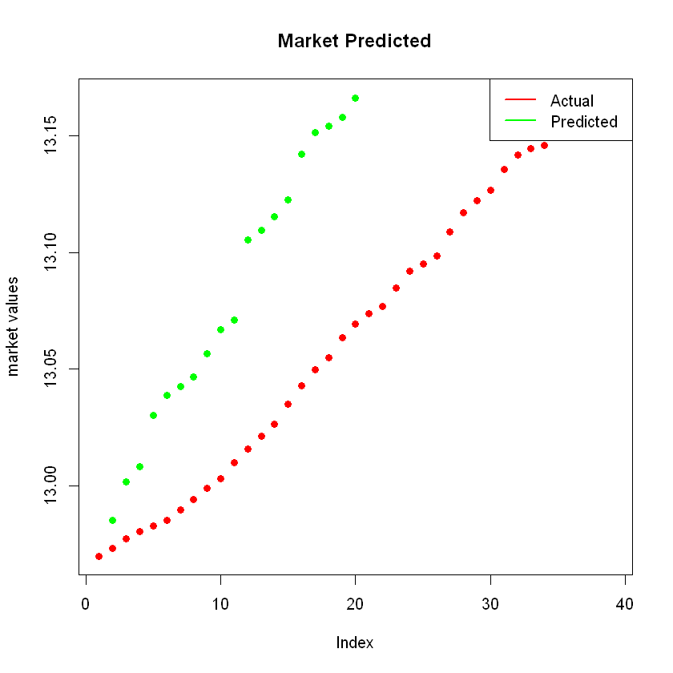

```r
#5.Plot the actual and predicted results for y variable.
plot(freeny$market.potential,type = "p",col = "red",pch = 19,ylab = "market values",main = "Market Predicted")
points(Pred , type = "p" ,col = "green",pch = 19)
legend("topright",inset = .0005,c("Actual","Predicted"),lwd = 2,lty = c(1,1,1,1,2),col = c("red","green"),)
```

## Good Job! You are done with the section!

## Section 3: Machine Learning: Logistic Regression

## Question 1

### Construct a logistic regression model using the Smarket dataset:

1. Your task is to predict the direction [Up: 1, Down:0].
2. Use a combination of variables that produces the lowest residual variance.
3. Plot the predicted vs. actual values.
4. Construct variable importance plot for all the variables.

```r
#install.packages('ISLR')
require('ISLR')
head(Smarket)
```

| Year | Lag1 | Lag2 | Lag3 | Lag4 | Lag5 | Volume | Today | Direction |
| --- | --- | --- | --- | --- | --- | --- | --- | --- |
| 2001 | 0.381 | -0.192 | -2.624 | -1.055 | 5.010 | 1.1913 | 0.959 | Up |
| 2001 | 0.959 | 0.381 | -0.192 | -2.624 | -1.055 | 1.2965 | 1.032 | Up |
| 2001 | 1.032 | 0.959 | 0.381 | -0.192 | -2.624 | 1.4112 | -0.623 | Down |
| 2001 | -0.623 | 1.032 | 0.959 | 0.381 | -0.192 | 1.2760 | 0.614 | Up |
| 2001 | 0.614 | -0.623 | 1.032 | 0.959 | 0.381 | 1.2057 | 0.213 | Up |
| 2001 | 0.213 | 0.614 | -0.623 | 1.032 | 0.959 | 1.3491 | 1.392 | Up |

```r
#1.Your task is to predict the direction [Up: 1, Down:0].
Sm <- Smarket[complete.cases(Smarket), ] #create a copy
#Look into the data structure
str(Sm)
#Change Y values to 1's and 0's
Sm$Direction <- ifelse(Sm$Direction == "Up" ,1,0)
#Sm$Direction <- factor(Sm$Direction,levels = c(0,1))
table(Sm$Direction)
```

```
'data.frame':	1250 obs. of  9 variables:
 $ Year     : num  2001 2001 2001 2001 2001 ...
 $ Lag1     : num  0.381 0.959 1.032 -0.623 0.614 ...
 $ Lag2     : num  -0.192 0.381 0.959 1.032 -0.623 ...
 $ Lag3     : num  -2.624 -0.192 0.381 0.959 1.032 ...
 $ Lag4     : num  -1.055 -2.624 -0.192 0.381 0.959 ...
 $ Lag5     : num  5.01 -1.055 -2.624 -0.192 0.381 ...
 $ Volume   : num  1.19 1.3 1.41 1.28 1.21 ...
 $ Today    : num  0.959 1.032 -0.623 0.614 0.213 ...
 $ Direction: Factor w/ 2 levels "Down","Up": 2 2 1 2 2 2 1 2 2 2 ...
```

```
  0   1
602 648
```

```r
#2.Use a combination of variables that produces the lowest residual variance.
mylogit <- glm(Direction ~ Lag1 + Lag2  + Lag3 + Lag4 + Lag5 + Volume,family = "binomial",data = Sm)
summary(mylogit)
```

```
Call:
glm(formula = Direction ~ Lag1 + Lag2 + Lag3 + Lag4 + Lag5 +
    Volume, family = "binomial", data = Sm)

Deviance Residuals:
   Min      1Q  Median      3Q     Max
-1.446  -1.203   1.065   1.145   1.326

Coefficients:
             Estimate Std. Error z value Pr(>|z|)
(Intercept) -0.126000   0.240736  -0.523    0.601
Lag1        -0.073074   0.050167  -1.457    0.145
Lag2        -0.042301   0.050086  -0.845    0.398
Lag3         0.011085   0.049939   0.222    0.824
Lag4         0.009359   0.049974   0.187    0.851
Lag5         0.010313   0.049511   0.208    0.835
Volume       0.135441   0.158360   0.855    0.392

(Dispersion parameter for binomial family taken to be 1)

    Null deviance: 1731.2  on 1249  degrees of freedom
Residual deviance: 1727.6  on 1243  degrees of freedom
AIC: 1741.6

Number of Fisher Scoring iterations: 3
```

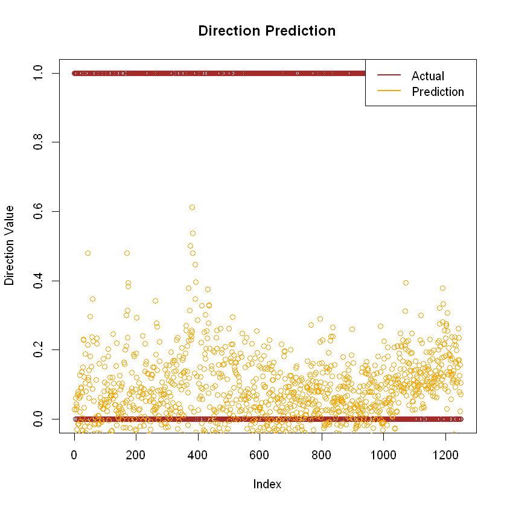

```r
#3.Plot the predicted vs. actual values.
predicted_data <- predict.glm(mylogit,Sm)
par(mfrow = c(1,1))
plot(Sm$Direction,type = "p",col = "brown" ,main = "Direction Prediction" ,ylab = "Direction Value")
points(predicted_data, type = "p", col = "orange")
legend("topright",inset = .0005,c("Actual","Prediction"),lwd = 2,lty = c(1,1,1,1,2),col = c("brown","orange"))
```

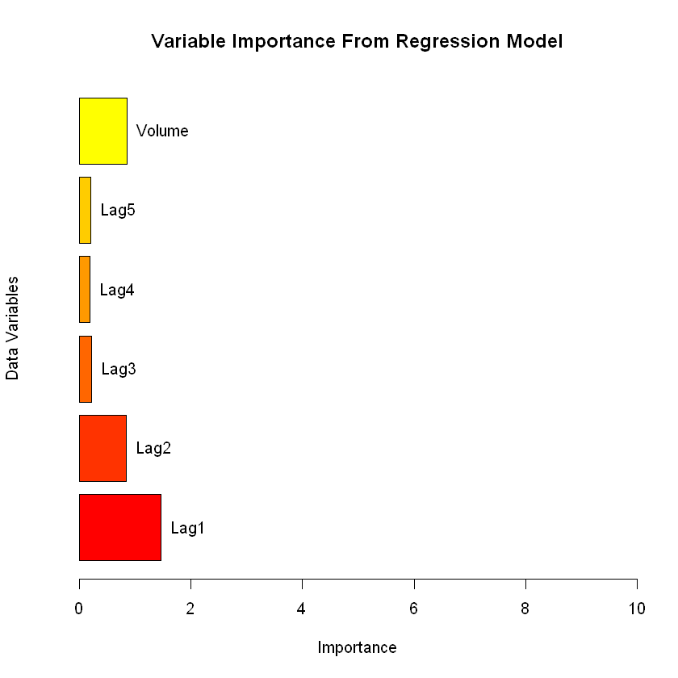

```r
#4.Construct variable importance plot for all the variables.
#install.packages("caret")
library(caret)
imp <- varImp(mylogit)
bp <- barplot(imp[,1],xlab = "Importance",ylab = "Data Variables",
main = "Variable Importance From Regression Model",col = heat.colors(7),horiz = TRUE,xlim = range(0,10))
a <- imp[,1]
names <- rownames(imp)
text(a,bp,names,pos = 4,cex = 1)
```

### Good Job! You are done with the section!

## Section 4: Machine Learning: Decision Trees and Random Forests

## Question 1

### Construct a decision tree for the following dataset:

1. Your task is to predict whether the sales will be High or Low.
2. You need to transform the Sale variable into binary variable: For sales less than 7.5, assign a value of Low and High otherwise. You will also need to transform ShelveLoc, Urban and US variables into binary variables.
3. Generate a decision tree and plot the diagram for the tree and plot predicted vs. actual results.
4. Attempt a random forest regression on the same dataset. Which model produces better results?

```r
#1.Your task is to predict whether the sales will be High or Low.
require('ISLR')
#head(Carseats)
Data <- Carseats
#library(rpart)
#fit <- rpart(Sales ~ .,method = "class",data = Carseats)
#summary(fit)
```

```r
#2.You need to transform the Sale variable into binary variable: For sales less than 7.5, assign a value of Low and High
#otherwise. You will also need to transform ShelveLoc, Urban and US variables into binary variables.
Data$Sales <- ifelse(Data$Sales <= 7.5 ,"Low","High")
```

```r
Data$ShelveLoc <- as.numeric(Data$ShelveLoc)
```

```r
Data$ShelveLoc <- ifelse(Data$ShelveLoc >= 2,"Yes","No")
Data$ShelveLoc <- ifelse(Data$ShelveLoc =="Yes",1,0)
```

```r
levels(Data$Urban) <- c(0,1)
levels(Data$US) <- c(0,1)
Data
```

| Sales | CompPrice | Income | Advertising | Population | Price | ShelveLoc | Age | Education | Urban | US |
| --- | --- | --- | --- | --- | --- | --- | --- | --- | --- | --- |
| High | 138 | 73 | 11 | 276 | 120 | 0 | 42 | 17 | 1 | 1 |
| High | 111 | 48 | 16 | 260 | 83 | 1 | 65 | 10 | 1 | 1 |
| High | 113 | 35 | 10 | 269 | 80 | 1 | 59 | 12 | 1 | 1 |
| Low | 117 | 100 | 4 | 466 | 97 | 1 | 55 | 14 | 1 | 1 |
| Low | 141 | 64 | 3 | 340 | 128 | 0 | 38 | 13 | 1 | 0 |
| High | 124 | 113 | 13 | 501 | 72 | 0 | 78 | 16 | 0 | 1 |
| Low | 115 | 105 | 0 | 45 | 108 | 1 | 71 | 15 | 1 | 0 |
| High | 136 | 81 | 15 | 425 | 120 | 1 | 67 | 10 | 1 | 1 |
| Low | 132 | 110 | 0 | 108 | 124 | 1 | 76 | 10 | 0 | 0 |
| Low | 132 | 113 | 0 | 131 | 124 | 1 | 76 | 17 | 0 | 1 |
| High | 121 | 78 | 9 | 150 | 100 | 0 | 26 | 10 | 0 | 1 |
| High | 117 | 94 | 4 | 503 | 94 | 1 | 50 | 13 | 1 | 1 |
| Low | 122 | 35 | 2 | 393 | 136 | 1 | 62 | 18 | 1 | 0 |
| High | 115 | 28 | 11 | 29 | 86 | 1 | 53 | 18 | 1 | 1 |
| High | 107 | 117 | 11 | 148 | 118 | 1 | 52 | 18 | 1 | 1 |
| High | 149 | 95 | 5 | 400 | 144 | 1 | 76 | 18 | 0 | 0 |
| High | 118 | 32 | 0 | 284 | 110 | 1 | 63 | 13 | 1 | 0 |
| High | 147 | 74 | 13 | 251 | 131 | 1 | 52 | 10 | 1 | 1 |
| High | 110 | 110 | 0 | 408 | 68 | 1 | 46 | 17 | 0 | 1 |
| High | 129 | 76 | 16 | 58 | 121 | 1 | 69 | 12 | 1 | 1 |
| Low | 125 | 90 | 2 | 367 | 131 | 1 | 35 | 18 | 1 | 1 |
| High | 134 | 29 | 12 | 239 | 109 | 1 | 62 | 18 | 0 | 1 |
| Low | 128 | 46 | 6 | 497 | 138 | 1 | 42 | 13 | 1 | 0 |
| Low | 121 | 31 | 0 | 292 | 109 | 1 | 79 | 10 | 1 | 0 |
| High | 145 | 119 | 16 | 294 | 113 | 0 | 42 | 12 | 1 | 1 |
| High | 139 | 32 | 0 | 176 | 82 | 1 | 54 | 11 | 0 | 0 |
| High | 107 | 115 | 11 | 496 | 131 | 1 | 50 | 11 | 0 | 1 |
| Low | 98 | 118 | 0 | 19 | 107 | 1 | 64 | 17 | 1 | 0 |
| Low | 103 | 74 | 0 | 359 | 97 | 0 | 55 | 11 | 1 | 1 |
| High | 104 | 99 | 15 | 226 | 102 | 0 | 58 | 17 | 1 | 1 |
| ... | ... | ... | ... | ... | ... | ... | ... | ... | ... | ... |
| High | 126 | 41 | 22 | 403 | 119 | 0 | 42 | 12 | 1 | 1 |
| High | 152 | 81 | 0 | 191 | 126 | 1 | 54 | 16 | 1 | 0 |
| High | 121 | 50 | 0 | 508 | 98 | 1 | 65 | 11 | 0 | 0 |
| Low | 137 | 71 | 0 | 402 | 116 | 1 | 78 | 17 | 1 | 0 |
| High | 131 | 47 | 7 | 90 | 118 | 1 | 47 | 12 | 1 | 1 |
| High | 132 | 46 | 4 | 206 | 124 | 1 | 73 | 11 | 1 | 0 |
| High | 141 | 60 | 19 | 319 | 92 | 1 | 44 | 11 | 1 | 1 |
| Low | 132 | 61 | 0 | 263 | 125 | 1 | 41 | 12 | 0 | 0 |
| Low | 133 | 88 | 3 | 105 | 119 | 1 | 79 | 12 | 1 | 1 |
| Low | 125 | 111 | 0 | 404 | 107 | 0 | 54 | 15 | 1 | 0 |
| High | 106 | 64 | 10 | 17 | 89 | 1 | 68 | 17 | 1 | 1 |
| Low | 124 | 65 | 21 | 496 | 151 | 0 | 77 | 13 | 1 | 1 |
| Low | 121 | 28 | 19 | 315 | 121 | 1 | 66 | 14 | 1 | 1 |
| High | 98 | 117 | 0 | 76 | 68 | 1 | 63 | 10 | 1 | 0 |
| High | 123 | 37 | 15 | 348 | 112 | 1 | 28 | 12 | 1 | 1 |
| Low | 131 | 73 | 13 | 455 | 132 | 1 | 62 | 17 | 1 | 1 |
| Low | 152 | 116 | 0 | 170 | 160 | 1 | 39 | 16 | 1 | 0 |
| High | 142 | 73 | 14 | 238 | 115 | 1 | 73 | 14 | 0 | 1 |
| High | 135 | 89 | 11 | 245 | 78 | 0 | 79 | 16 | 1 | 1 |
| High | 128 | 42 | 8 | 328 | 107 | 1 | 35 | 12 | 1 | 1 |
| Low | 108 | 75 | 9 | 61 | 111 | 1 | 67 | 12 | 1 | 1 |
| Low | 153 | 63 | 0 | 49 | 124 | 0 | 56 | 16 | 1 | 0 |
| Low | 129 | 42 | 13 | 315 | 130 | 0 | 34 | 13 | 1 | 1 |
| Low | 109 | 51 | 10 | 26 | 120 | 1 | 30 | 17 | 0 | 1 |
| Low | 130 | 58 | 19 | 366 | 139 | 0 | 33 | 16 | 1 | 1 |
| High | 138 | 108 | 17 | 203 | 128 | 1 | 33 | 14 | 1 | 1 |
| Low | 139 | 23 | 3 | 37 | 120 | 1 | 55 | 11 | 0 | 1 |
| Low | 162 | 26 | 12 | 368 | 159 | 1 | 40 | 18 | 1 | 1 |
| Low | 100 | 79 | 7 | 284 | 95 | 0 | 50 | 12 | 1 | 1 |
| High | 134 | 37 | 0 | 27 | 120 | 1 | 49 | 16 | 1 | 1 |

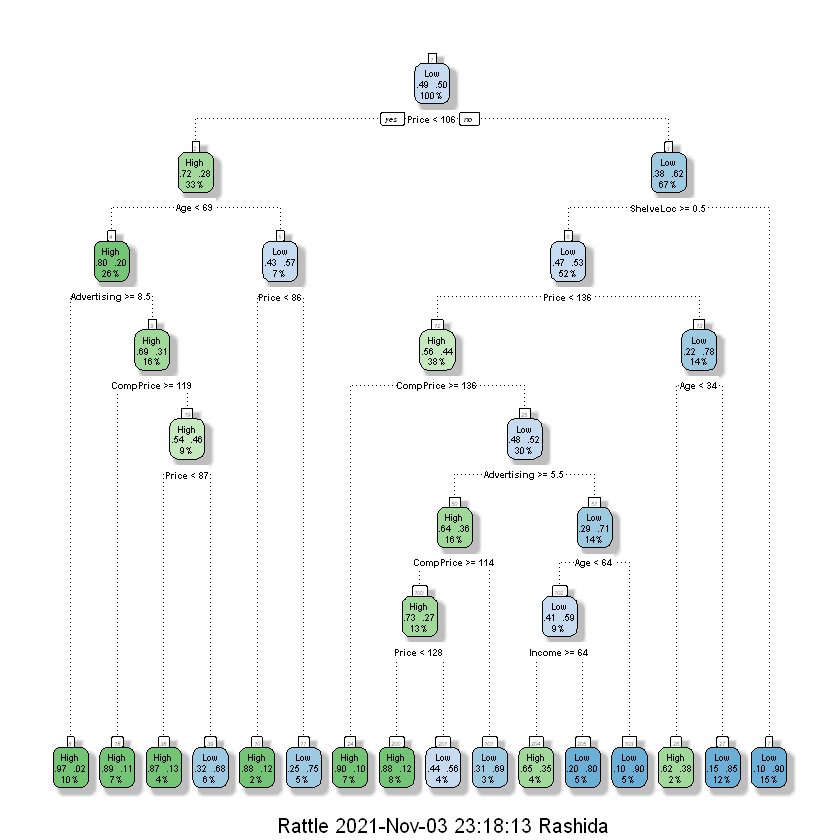

```r
#3.Generate a decision tree and plot the diagram for the tree and plot predicted vs. actual results.
#install.packages("rpart")
#install.packages("rattle")
library(rattle)
library(rpart)
tree <- rpart(Sales ~ .,method = "class", data = Data)
fancyRpartPlot(tree)
```

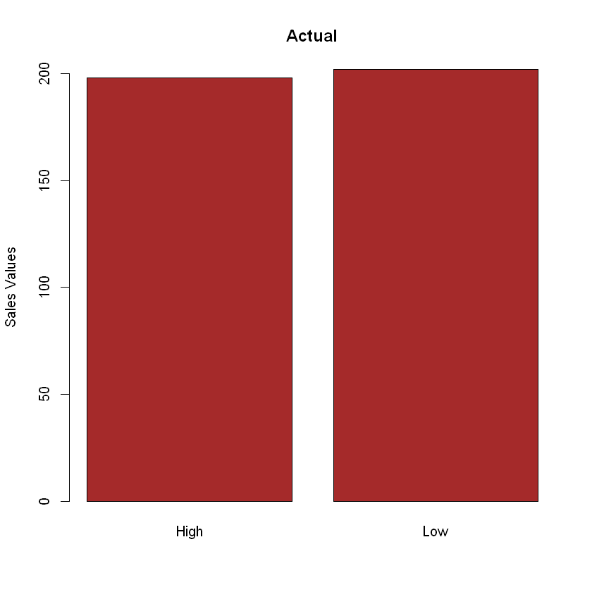

```r
#3.plot predicted vs. actual results.
Data$Sales = factor(Data$Sales)
#Actual:-
plot(Data$Sales,col="brown",main = "Actual",ylab = "Sales Values")
```

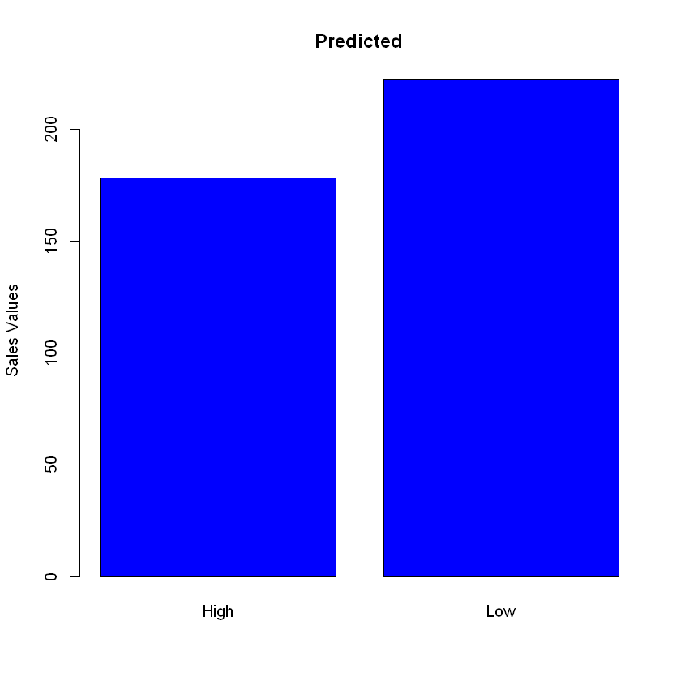

```r
#3.plot predicted vs. actual results.
#Prediction
Predicted_data <-predict(tree,Data,type = "class")
plot(Predicted_data,col = "blue",main = "Predicted",ylab = "Sales Values")
```

```
Call:
 randomForest(formula = Sales ~ ., data = Data, mtry = 4, ntree = 500)
               Type of random forest: classification
                     Number of trees: 500
No. of variables tried at each split: 4

        OOB estimate of  error rate: 22.5%
Confusion matrix:
     High Low class.error
High  145  53   0.2676768
Low    37 165   0.1831683
```

|  | MeanDecreaseGini |
| --- | --- |
| CompPrice | 26.348657 |
| Income | 21.910454 |
| Advertising | 23.600897 |
| Population | 17.855195 |
| Price | 53.466176 |
| ShelveLoc | 14.897101 |
| Age | 26.106014 |
| Education | 10.760024 |
| Urban | 2.381419 |
| US | 2.119357 |

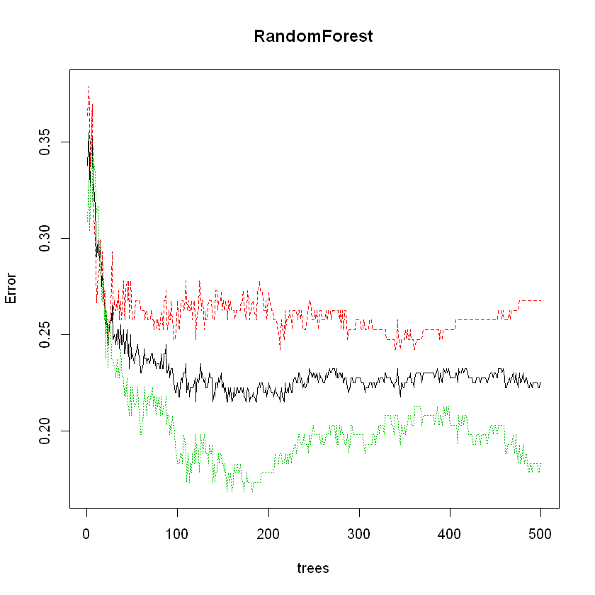

```r
#4.Attempt a random forest regression on the same dataset. Which model produces better results?
library(randomForest)
RandomForest <- randomForest(Sales ~ .,data = Data,mtry = 4,ntree = 500)
print(RandomForest)
plot(RandomForest)
importance(RandomForest)
#Random Forest produces better result than decision tree.
```

### Good Job! You are done with the section!

## Section 5: Neural Networks

## Question 1

#### Construct a neural network for the same dataset:

1. Your task is to predict whether the sales will be High or Low.
2. Perform necessary data transformations as required.
3. Generate neural network with 3 layers and 2,3,4 nodes respectively.
4. Plot the nn.

```r
#1.Your task is to predict whether the sales will be High or Low.
#install.packages('neuralnet')
#library(neuralnet)
#library(tidyverse)
DATA <- Data
DATA
```

| Sales | CompPrice | Income | Advertising | Population | Price | ShelveLoc | Age | Education | Urban | US |
| --- | --- | --- | --- | --- | --- | --- | --- | --- | --- | --- |
| High | 138 | 73 | 11 | 276 | 120 | 0 | 42 | 17 | 1 | 1 |
| High | 111 | 48 | 16 | 260 | 83 | 1 | 65 | 10 | 1 | 1 |
| High | 113 | 35 | 10 | 269 | 80 | 1 | 59 | 12 | 1 | 1 |
| Low | 117 | 100 | 4 | 466 | 97 | 1 | 55 | 14 | 1 | 1 |
| Low | 141 | 64 | 3 | 340 | 128 | 0 | 38 | 13 | 1 | 0 |
| High | 124 | 113 | 13 | 501 | 72 | 0 | 78 | 16 | 0 | 1 |
| Low | 115 | 105 | 0 | 45 | 108 | 1 | 71 | 15 | 1 | 0 |
| High | 136 | 81 | 15 | 425 | 120 | 1 | 67 | 10 | 1 | 1 |
| Low | 132 | 110 | 0 | 108 | 124 | 1 | 76 | 10 | 0 | 0 |
| Low | 132 | 113 | 0 | 131 | 124 | 1 | 76 | 17 | 0 | 1 |
| High | 121 | 78 | 9 | 150 | 100 | 0 | 26 | 10 | 0 | 1 |
| High | 117 | 94 | 4 | 503 | 94 | 1 | 50 | 13 | 1 | 1 |
| Low | 122 | 35 | 2 | 393 | 136 | 1 | 62 | 18 | 1 | 0 |
| High | 115 | 28 | 11 | 29 | 86 | 1 | 53 | 18 | 1 | 1 |
| High | 107 | 117 | 11 | 148 | 118 | 1 | 52 | 18 | 1 | 1 |
| High | 149 | 95 | 5 | 400 | 144 | 1 | 76 | 18 | 0 | 0 |
| High | 118 | 32 | 0 | 284 | 110 | 1 | 63 | 13 | 1 | 0 |
| High | 147 | 74 | 13 | 251 | 131 | 1 | 52 | 10 | 1 | 1 |
| High | 110 | 110 | 0 | 408 | 68 | 1 | 46 | 17 | 0 | 1 |
| High | 129 | 76 | 16 | 58 | 121 | 1 | 69 | 12 | 1 | 1 |
| Low | 125 | 90 | 2 | 367 | 131 | 1 | 35 | 18 | 1 | 1 |
| High | 134 | 29 | 12 | 239 | 109 | 1 | 62 | 18 | 0 | 1 |
| Low | 128 | 46 | 6 | 497 | 138 | 1 | 42 | 13 | 1 | 0 |
| Low | 121 | 31 | 0 | 292 | 109 | 1 | 79 | 10 | 1 | 0 |
| High | 145 | 119 | 16 | 294 | 113 | 0 | 42 | 12 | 1 | 1 |
| High | 139 | 32 | 0 | 176 | 82 | 1 | 54 | 11 | 0 | 0 |
| High | 107 | 115 | 11 | 496 | 131 | 1 | 50 | 11 | 0 | 1 |
| Low | 98 | 118 | 0 | 19 | 107 | 1 | 64 | 17 | 1 | 0 |
| Low | 103 | 74 | 0 | 359 | 97 | 0 | 55 | 11 | 1 | 1 |
| High | 104 | 99 | 15 | 226 | 102 | 0 | 58 | 17 | 1 | 1 |
| ... | ... | ... | ... | ... | ... | ... | ... | ... | ... | ... |
| High | 126 | 41 | 22 | 403 | 119 | 0 | 42 | 12 | 1 | 1 |
| High | 152 | 81 | 0 | 191 | 126 | 1 | 54 | 16 | 1 | 0 |
| High | 121 | 50 | 0 | 508 | 98 | 1 | 65 | 11 | 0 | 0 |
| Low | 137 | 71 | 0 | 402 | 116 | 1 | 78 | 17 | 1 | 0 |
| High | 131 | 47 | 7 | 90 | 118 | 1 | 47 | 12 | 1 | 1 |
| High | 132 | 46 | 4 | 206 | 124 | 1 | 73 | 11 | 1 | 0 |
| High | 141 | 60 | 19 | 319 | 92 | 1 | 44 | 11 | 1 | 1 |
| Low | 132 | 61 | 0 | 263 | 125 | 1 | 41 | 12 | 0 | 0 |
| Low | 133 | 88 | 3 | 105 | 119 | 1 | 79 | 12 | 1 | 1 |
| Low | 125 | 111 | 0 | 404 | 107 | 0 | 54 | 15 | 1 | 0 |
| High | 106 | 64 | 10 | 17 | 89 | 1 | 68 | 17 | 1 | 1 |
| Low | 124 | 65 | 21 | 496 | 151 | 0 | 77 | 13 | 1 | 1 |
| Low | 121 | 28 | 19 | 315 | 121 | 1 | 66 | 14 | 1 | 1 |
| High | 98 | 117 | 0 | 76 | 68 | 1 | 63 | 10 | 1 | 0 |
| High | 123 | 37 | 15 | 348 | 112 | 1 | 28 | 12 | 1 | 1 |
| Low | 131 | 73 | 13 | 455 | 132 | 1 | 62 | 17 | 1 | 1 |
| Low | 152 | 116 | 0 | 170 | 160 | 1 | 39 | 16 | 1 | 0 |
| High | 142 | 73 | 14 | 238 | 115 | 1 | 73 | 14 | 0 | 1 |
| High | 135 | 89 | 11 | 245 | 78 | 0 | 79 | 16 | 1 | 1 |
| High | 128 | 42 | 8 | 328 | 107 | 1 | 35 | 12 | 1 | 1 |
| Low | 108 | 75 | 9 | 61 | 111 | 1 | 67 | 12 | 1 | 1 |
| Low | 153 | 63 | 0 | 49 | 124 | 0 | 56 | 16 | 1 | 0 |
| Low | 129 | 42 | 13 | 315 | 130 | 0 | 34 | 13 | 1 | 1 |
| Low | 109 | 51 | 10 | 26 | 120 | 1 | 30 | 17 | 0 | 1 |
| Low | 130 | 58 | 19 | 366 | 139 | 0 | 33 | 16 | 1 | 1 |
| High | 138 | 108 | 17 | 203 | 128 | 1 | 33 | 14 | 1 | 1 |
| Low | 139 | 23 | 3 | 37 | 120 | 1 | 55 | 11 | 0 | 1 |
| Low | 162 | 26 | 12 | 368 | 159 | 1 | 40 | 18 | 1 | 1 |
| Low | 100 | 79 | 7 | 284 | 95 | 0 | 50 | 12 | 1 | 1 |
| High | 134 | 37 | 0 | 27 | 120 | 1 | 49 | 16 | 1 | 1 |

```r
#2.Perform necessary data transformations as required
#library(tidyverse)
normalize <- function(x){
    return(x-min(x) / max(x)-min(x))
}
DATA <- Carseats[complete.cases(Carseats), ]
DATA <- DATA %>% select_if(is.numeric)
DfNorm <- as.data.frame(lapply(DATA,normalize))
```

```r
#library(neuralnet)
```

```r
#3.Generate neural network with 3 layers and 2,3,4 nodes respectively.
n <- nrow(DATA)
smp_size <- floor (0.7 * n)
set.seed(123)
index <- sample(seq_len(n),size = smp_size)
train <- DfNorm[index,]
test <- DfNorm[-index,]
#f = as.formula(Sales ~ Income + Advertising + Population + Price + Age)
nn <- neuralnet(Sales ~ Income + Advertising + Population + Price + Age, data = train, hidden = c(2,3,4),act.fct = "logistic"
                ,linear.output = TRUE )
```

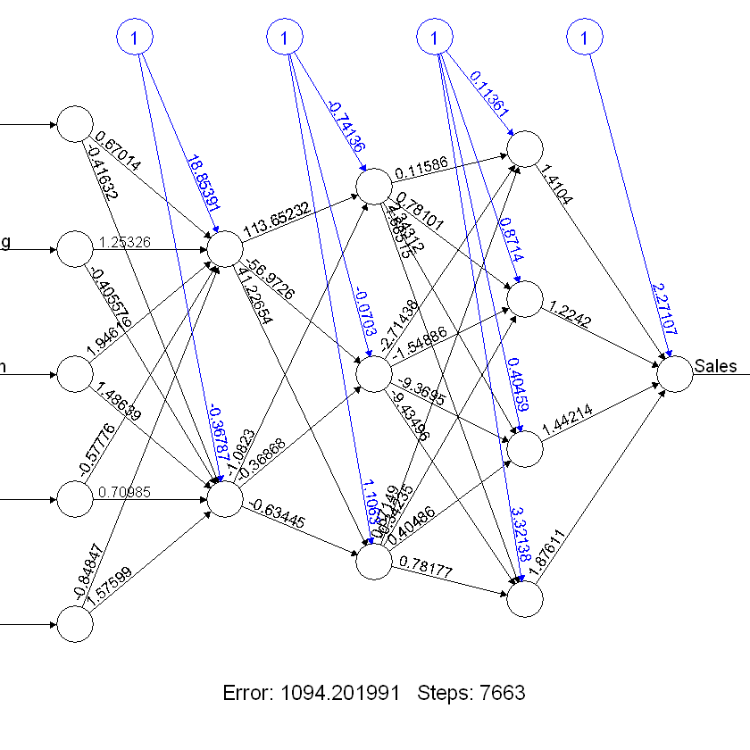

```r
#4.Plot the nn.
plot(nn,rep = "best")
```

### Good Job! You are done with the section!

## Section 6: Performance Evaluation

# Question 1

#### For the above decision tree, logistic regression and neural network models:

1. Construct a confusion matrix.
2. Plot out the ROC and AUC cruves.
3. For the datasets of Carseats, which model produced the highest accuracy with lowest variance?

```r
#For the above decision tree
#1.Construct a confusion matrix.
#library(caret)
#install.packages("e1071")
#library(e1071)
result <- confusionMatrix(Predicted_data,Data$Sales)
result
```

```
Confusion Matrix and Statistics

          Reference
Prediction High Low
      High  155  23
      Low    43 179

               Accuracy : 0.835
                 95% CI : (0.7949, 0.87)
    No Information Rate : 0.505
    P-Value [Acc > NIR] : < 2e-16

                  Kappa : 0.6696

 Mcnemar's Test P-Value : 0.01935

            Sensitivity : 0.7828
            Specificity : 0.8861
         Pos Pred Value : 0.8708
         Neg Pred Value : 0.8063
             Prevalence : 0.4950
         Detection Rate : 0.3875
   Detection Prevalence : 0.4450
      Balanced Accuracy : 0.8345

       'Positive' Class : High
```

```r
#For the above logistic regression models:
#1.Construct a confusion matrix.
glm_pred = rep("Up",length(predicted_data))
glm_pred[predicted_data < 0.5] = "Down"
glm_pred = factor(glm_pred)
confusionMatrix(glm_pred,Smarket$Direction)
```

```
Confusion Matrix and Statistics

          Reference
Prediction Down  Up
      Down  600 647
      Up      2   1

               Accuracy : 0.4808
                 95% CI : (0.4528, 0.5089)
    No Information Rate : 0.5184
    P-Value [Acc > NIR] : 0.9964

                  Kappa : -0.0017

 Mcnemar's Test P-Value : <2e-16

            Sensitivity : 0.996678
            Specificity : 0.001543
         Pos Pred Value : 0.481155
         Neg Pred Value : 0.333333
             Prevalence : 0.481600
         Detection Rate : 0.480000
   Detection Prevalence : 0.997600
      Balanced Accuracy : 0.499110

       'Positive' Class : Down
```

# Good Job! You are done with the course!